# Midterm2 Review

Bryan Liu

November 8, 2018

# Problem 1: variable transformations

Suppose we had the model $y_i = \beta_0 + \beta_1 x_i + e_i$, where $e_i \sim \mathcal{N}(0, (\beta_0 + \beta_1 x_i)^2)$.

## a.

Set $\beta_0 = 1$ and $\beta_1 = 20$.

Generate 100 $x$’s from a uniform distribution on $[0, 1]$, and subsequently generate the $y$’s.

Fit a regression line of $y$ on $x$, and plot the residuals against x.

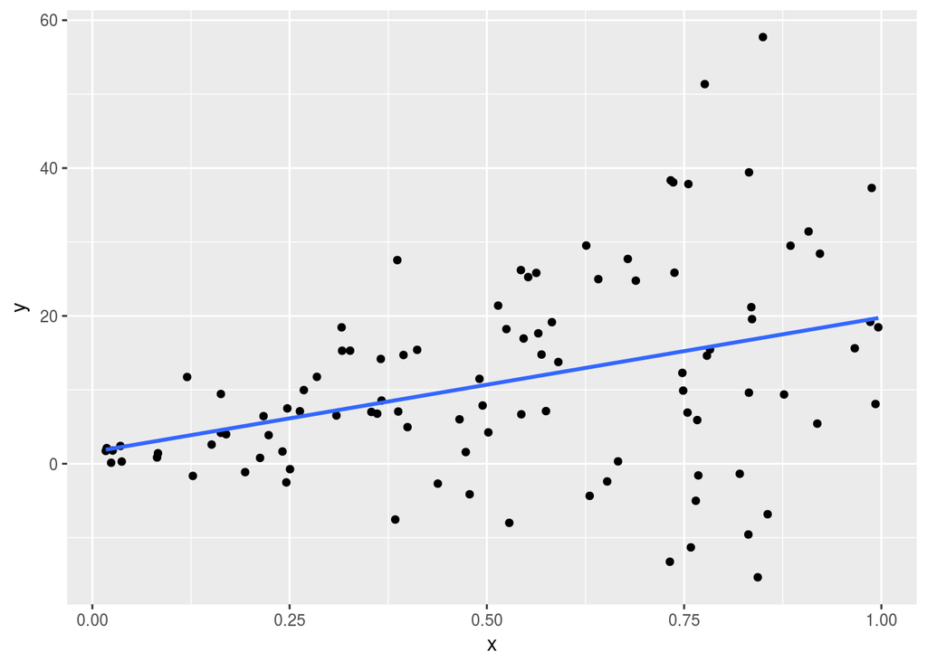

```r
# set coefficients
beta0 <- 1
beta1 <- 20

# generate data
x <- runif(100)

y <- beta0 + beta1 * x + rnorm(100, mean = 0, sd = (beta0 + beta1 * x))

# plot x vs y
ggplot() + geom_point(aes(x = x, y = y)) +
    geom_smooth(aes(x = x, y = y), method = 'lm', se = FALSE)
```

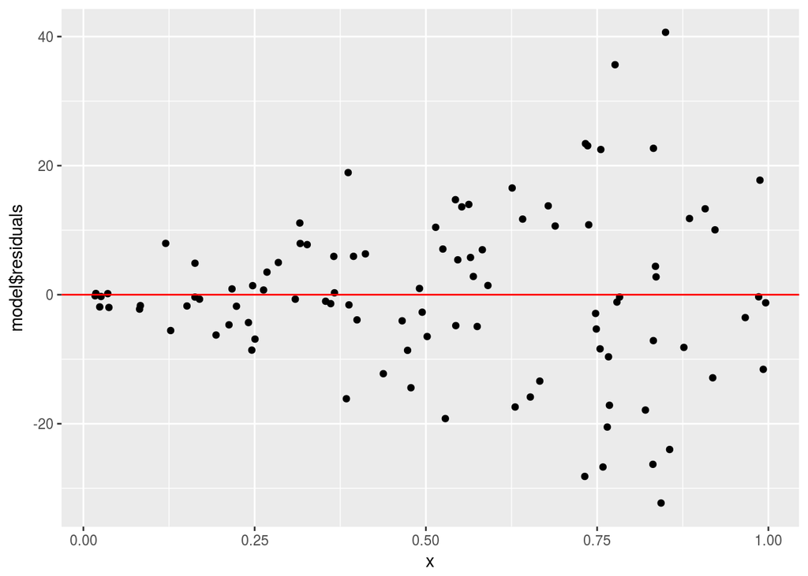

```r
# fit the linear model
model <- lm(y ~ x, data = data.frame(x = x, y = y))

# get residuals
ggplot() + geom_point(aes(x = x, y = model$residuals)) +
  geom_hline(yintercept = 0, color = 'red')
```

## b.

Which assumption in linear models is violated?

Propose a variance-stabilizing tranformation to fix this problem.

# c.

Suppose we had $y_i = \beta_0 + \beta_1 x_{1i} + \beta_2 x_{2i} + \beta_3 \exp(2 \cdot x_{3i}) + e_i$, where $e_i\sim \mathcal{N}(0, 1)$.

Generate the covariate matrix $X \in \mathbb{R}^{100 \times 3}$ whereby each entry of $X$ is independent and drawn uniformly on $[0, 1]$. Generate the $y$’s from these $X$’s.

Fit a linear regression line of $y$ on $X$ (without taking into account the non-linearity in $x_3$), and make partial residual plots for all three variables. Are you able to detect the non-linearity in $x_3$?

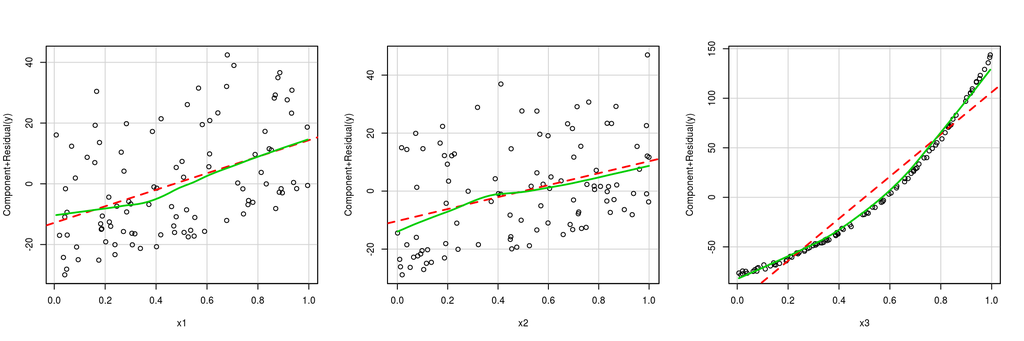

```r
# set coefficients
beta0 <- 3
beta1 <- 25
beta2 <- 20
beta3 <- 35

# generate data
X <- matrix(runif(300), ncol = 3)

y <- beta0 + beta1 * X[, 1] +
            beta2 * X[, 2]  +
            beta3 * exp(2 * X[, 3])  +
            rnorm(100, mean = 0, sd = 1)

# create dataframe
my_data <- data.frame(y = y,
                      x1 = X[, 1],
                      x2 = X[, 2],
                      x3 = X[, 3])

#
model <- lm(y ~ ., data = my_data)
par(mfrow = c(1,3))
crPlot(model, 'x1')
crPlot(model, 'x2')
crPlot(model, 'x3')
```

# d.

Transform $x_3$ so that we are fitting to the correct model. Re-create the partial residual plots. Do they look better?

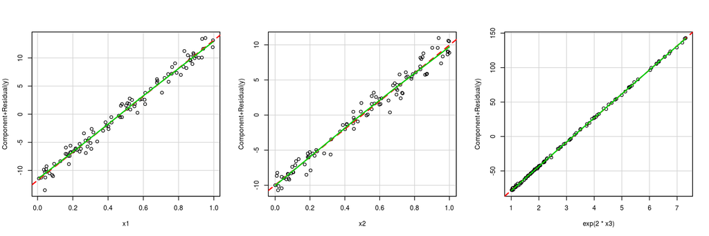

```r
model_correct <- lm(y ~ x1 + x2 + exp(2 * x3), data = my_data)

par(mfrow = c(1,3))
crPlot(model_correct, 'x1')
crPlot(model_correct, 'x2')
crPlot(model_correct, 'exp(2 * x3)')
```

# e.

For more fun, visit exercise 12.6 in the book.

# Problem 2: colinearity

This question provides a counter-example to one of the true/false questions on HW5.

Consider the data-generating process:

$$\begin{align}
x_1 &\sim \text{Uniform}[0, 1]\\
x_2 &\sim -x_1 + \mathcal{N}(0, 0.01)\\
y &\sim x_1 + x_2 + + \mathcal{N}(0, 0.0001)
\end{align}$$

Generate 100 datapoints according to this model, and fit a regression of $y$ on $x_1$. What is the $T$ statistic for the coefficient in front of $x_1$? Note that $y$ is actually independent of $x_1$; does the $T$ statistic agree with this fact?

Now fit a regression fo $y$ on both $x_1$ and $x_2$. What are the $T$-statistics now?

```r
# draw data
x1 <- runif(100)
x2 <- -x1 + rnorm(100, 0, 0.01)

y <- x2 + x1 + rnorm(100, 0, 0.0001)

# fit on only x1
model <- lm(y ~ x1, data = data.frame(y = y, x1 = x1, x2 = x2))
summary(model)
```

```
##
## Call:
## lm(formula = y ~ x1, data = data.frame(y = y, x1 = x1, x2 = x2))
##
## Residuals:
##        Min         1Q     Median         3Q        Max
## -0.0314903 -0.0067238 -0.0003653  0.0077092  0.0294548
##
## Coefficients:
##               Estimate Std. Error t value Pr(>|t|)
## (Intercept)  1.298e-04  2.316e-03   0.056    0.955
## x1          -9.229e-05  3.897e-03  -0.024    0.981
##
## Residual standard error: 0.01119 on 98 degrees of freedom
## Multiple R-squared:  5.721e-06,  Adjusted R-squared:  -0.0102
## F-statistic: 0.0005607 on 1 and 98 DF,  p-value: 0.9812
```

```r
# fit on both x1 and x2
model2 <- lm(y ~ x1 + x2, data = data.frame(y = y, x1 = x1, x2 = x2))
summary(model2)
```

```
##
## Call:
## lm(formula = y ~ x1 + x2, data = data.frame(y = y, x1 = x1, x2 = x2))
##
## Residuals:
##        Min         1Q     Median         3Q        Max
## -2.437e-04 -8.588e-05  1.322e-05  7.838e-05  2.755e-04
##
## Coefficients:
##               Estimate Std. Error  t value Pr(>|t|)
## (Intercept) -1.499e-05  2.113e-05   -0.709     0.48
## x1           1.001e+00  9.232e-04 1083.890   <2e-16 ***
## x2           1.001e+00  9.224e-04 1084.795   <2e-16 ***
## ---
## Signif. codes:  0 '***' 0.001 '**' 0.01 '*' 0.05 '.' 0.1 ' ' 1
##
## Residual standard error: 0.0001021 on 97 degrees of freedom
## Multiple R-squared:  0.9999, Adjusted R-squared:  0.9999
## F-statistic: 5.884e+05 on 2 and 97 DF,  p-value: < 2.2e-16
```

# Problem 3:

Show that in simple linear regression, that the hat-value is
$$h_i = \frac{1}{n} + \frac{(x_i - \bar x)^2}{\sum_{j=1}^n (x_j - \bar x)^2}$$

# Problem 4:

Show that the correlation between the residuals $\hat e_i$ and $y_i$ is $\sqrt{1 - h_{ii}}$.

# Problem 5: Mallows Cp

Let $y = X\beta + \epsilon$, $\epsilon \sim \mathcal{N}(0, \sigma^2 I_{n\times n})$.

Let $H(m)$ be the projection matrix onto a subset of the columns $X$.

a). Show that
$$E\|H(m)y - X\beta\|^2 = \sigma^2 (p(m) + 1) + \beta^T X^T(I - H(m))X\beta$$

b). Show that when $M$ is the full model, this expectation equals $\sigma^2(p(M) + 1)$.

c). Show that
$$RSS(m) - \sigma^2(n - 2 - p(m))$$
is an unbiased estimate for the above expectation.